# Airbnb

```python
%load_ext nb_black
import numpy as np
import pandas as pd
import matplotlib.pyplot as plt
import seaborn as sns
from sklearn.model_selection import train_test_split
from sklearn.linear_model import LinearRegression
from sklearn.metrics import mean_absolute_error, mean_squared_error, r2_score
import warnings

pd.set_option("display.max_columns", None)
warnings.filterwarnings("ignore")
```

```
The nb_black extension is already loaded. To reload it, use:
  %reload_ext nb_black
```

```python
#Load in dataset and deal with missing values
df = pd.read_csv("AirBNB.csv")

df = df.dropna()
print(df)
print(f"There are {df.shape[0]} rows and {df.shape[1]} columns.")

#Let's drop id, since it has no impact or correlation on any other variable.
df = df.drop("id", axis=1)
```

```
             id        room_type  accommodates  bathrooms cancellation_policy  \
0       6901257  Entire home/apt           3.0        1.0              strict
1       6304928  Entire home/apt           7.0        1.0              strict
2       7919400  Entire home/apt           5.0        1.0            moderate
4       3808709  Entire home/apt           2.0        1.0            moderate
5      12422935     Private room           2.0        1.0              strict
...         ...              ...           ...        ...                 ...
74104  14934112  Entire home/apt           2.0        1.0              strict
74105    808802     Private room           2.0        1.0            moderate
74107  13281809  Entire home/apt           4.0        2.0            moderate
74108  18688039  Entire home/apt           5.0        1.0            moderate
74110   3534845  Entire home/apt           4.0        1.0            moderate

      cleaning_fee instant_bookable  review_scores_rating  bedrooms  beds  \
0             True                f                 100.0       1.0   1.0
```

[output cut: 26 more lines]

```python
# Data Preprocessing
# We should replace some categorical variables with ones that are easier to read, or boolean for T/F.
replacer = {
    "room_type": {
        "Entire home/apt": "Entire",
        "Private room": "Private",
        "Shared room": "Shared",
    },
    "instant_bookable": {"f": 0, "t": 1},
    "cleaning_fee": {False: 0, True: 1},
}
df = df.replace(replacer)

#Let's cast the floats to ints
df["bathrooms"] = df["bathrooms"].astype(int)
df["beds"] = df["beds"].astype(int)
df["bedrooms"] = df["bedrooms"].astype(int)
df["accommodates"] = df["accommodates"].astype(int)
print(df)
```

```
      room_type  accommodates  bathrooms cancellation_policy  cleaning_fee  \
0        Entire             3          1              strict             1
1        Entire             7          1              strict             1
2        Entire             5          1            moderate             1
4        Entire             2          1            moderate             1
5       Private             2          1              strict             1
...         ...           ...        ...                 ...           ...
74104    Entire             2          1              strict             1
74105   Private             2          1            moderate             1
74107    Entire             4          2            moderate             1
74108    Entire             5          1            moderate             1
74110    Entire             4          1            moderate             0

       instant_bookable  review_scores_rating  bedrooms  beds  log_price
0                     0                 100.0         1     1   5.010635
1                     1                  93.0         3     3   5.129899
2                     1                  92.0         1     3   4.976734
4                     1                  40.0         0     1   4.744932
5                     1                 100.0         1     1   4.442651
...                 ...                   ...       ...   ...        ...
74104                 0                 100.0         1     1   4.356709
74105                 0                  91.0         1     1   4.248495
74107                 0                  93.0         2     4   5.043425
74108                 1                  94.0         2     2   5.220356
74110                 0                  96.0         1     2   4.852030

[57119 rows x 10 columns]
```

```python
df.describe().T

# Taking a look at this data, we can see that most of this data is categorical.
# We can see that there are more beds than bedrooms, indicating the option of
# shared rooms.
```

|  | count | mean | std | min | 25% | 50% | 75% | max |
| --- | --- | --- | --- | --- | --- | --- | --- | --- |
| accommodates | 57119.0 | 3.222798 | 2.146140 | 1.0 | 2.000000 | 2.00000 | 4.000000 | 16.000000 |
| bathrooms | 57119.0 | 1.186593 | 0.527531 | 0.0 | 1.000000 | 1.00000 | 1.000000 | 8.000000 |
| cleaning_fee | 57119.0 | 0.794902 | 0.403777 | 0.0 | 1.000000 | 1.00000 | 1.000000 | 1.000000 |
| instant_bookable | 57119.0 | 0.268475 | 0.443170 | 0.0 | 0.000000 | 0.00000 | 1.000000 | 1.000000 |
| review_scores_rating | 57119.0 | 94.076384 | 7.828712 | 20.0 | 92.000000 | 96.00000 | 100.000000 | 100.000000 |
| bedrooms | 57119.0 | 1.261822 | 0.842778 | 0.0 | 1.000000 | 1.00000 | 1.000000 | 10.000000 |
| beds | 57119.0 | 1.740016 | 1.266989 | 0.0 | 1.000000 | 1.00000 | 2.000000 | 18.000000 |
| log_price | 57119.0 | 4.749993 | 0.668900 | 0.0 | 4.304065 | 4.70048 | 5.164786 | 7.600402 |

```python
#I will now copy some useful functions from the previously given code below
def histogram_boxplot(data, feature, figsize=(12, 7), kde=False, bins=None):
    """
    Boxplot and histogram combined

    data: dataframe
    feature: dataframe column
    figsize: size of figure (default (12,7))
    kde: whether to the show density curve (default False)
    bins: number of bins for histogram (default None)
    """
    f2, (ax_box2, ax_hist2) = plt.subplots(
        nrows=2,  # Number of rows of the subplot grid= 2
        sharex=True,  # x-axis will be shared among all subplots
        gridspec_kw={"height_ratios": (0.25, 0.75)},
        figsize=figsize,
    )  # creating the 2 subplots
    sns.boxplot(
        data=data, x=feature, ax=ax_box2, showmeans=True, color="violet"
    )  # boxplot will be created and a star will indicate the mean value of the column
    sns.histplot(
        data=data, x=feature, kde=kde, ax=ax_hist2, bins=bins, palette="winter"
    ) if bins else sns.histplot(
        data=data, x=feature, kde=kde, ax=ax_hist2
    )  # For histogram
    ax_hist2.axvline(
        data[feature].mean(), color="green", linestyle="--"
    )  # Add mean to the histogram
    ax_hist2.axvline(
        data[feature].median(), color="black", linestyle="-"
    )  # Add median to the histogram


def labeled_barplot(data, feature, perc=False, n=None):
    """
    Barplot with percentage at the top

    data: dataframe
    feature: dataframe column
    perc: whether to display percentages instead of count (default is False)
    n: displays the top n category levels (default is None, i.e., display all levels)
    """

    total = len(data[feature])  # length of the column
    count = data[feature].nunique()
    if n is None:
        plt.figure(figsize=(count + 1, 5))
    else:
        plt.figure(figsize=(n + 1, 5))

    plt.xticks(rotation=90, fontsize=15)
    ax = sns.countplot(
        data=data,
        x=feature,
        palette="Paired",
        order=data[feature].value_counts().index[:n].sort_values(),
    )

    for p in ax.patches:
        if perc == True:
            label = "{:.1f}%".format(
                100 * p.get_height() / total
            )  # percentage of each class of the category
        else:
            label = p.get_height()  # count of each level of the category

        x = p.get_x() + p.get_width() / 2  # width of the plot
        y = p.get_height()  # height of the plot

        ax.annotate(
            label,
            (x, y),
            ha="center",
            va="center",
            size=12,
            xytext=(0, 5),
            textcoords="offset points",
        )  # annotate the percentage

    plt.show()  # show the plot


def adj_r2_score(predictors, targets, predictions):
    r2 = r2_score(targets, predictions)
    n = predictors.shape[0]
    k = predictors.shape[1]
    return 1 - ((1 - r2) * (n - 1) / (n - k - 1))


# function to compute MAPE
def mape_score(targets, predictions):
    return np.mean(np.abs(targets - predictions) / targets) * 100


# function to compute different metrics to check performance of a regression model
def model_performance_regression(model, predictors, target):
    """
    Function to compute different metrics to check regression model performance

    model: regressor
    predictors: independent variables
    target: dependent variable
    """

    # predicting using the independent variables
    pred = model.predict(predictors)

    r2 = r2_score(target, pred)  # to compute R-squared
    adjr2 = adj_r2_score(predictors, target, pred)  # to compute adjusted R-squared
    rmse = np.sqrt(mean_squared_error(target, pred))  # to compute RMSE
    mae = mean_absolute_error(target, pred)  # to compute MAE
    mape = mape_score(target, pred)  # to compute MAPE

    # creating a dataframe of metrics
    df_perf = pd.DataFrame(
        {
            "RMSE": rmse,
            "MAE": mae,
            "R-squared": r2,
            "Adj. R-squared": adjr2,
            "MAPE": mape,
        },
        index=[0],
    )

    return df_perf
```

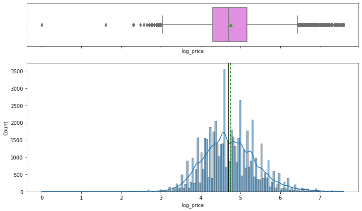

```python
histogram_boxplot(df, "log_price", kde=True)

# It seems that most of the prices are around 10^4.75, or around 56,000 on avg.
```

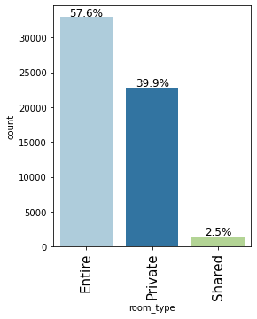

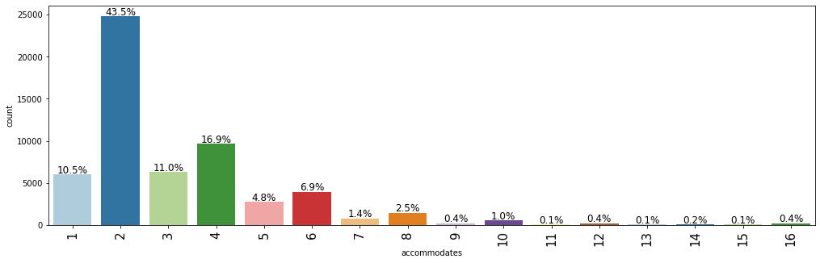

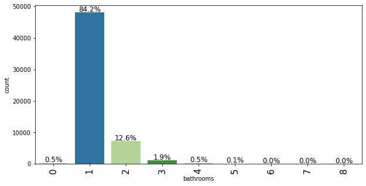

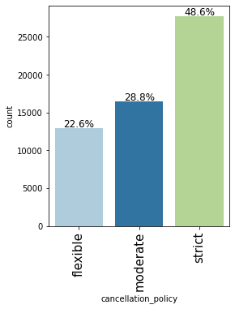

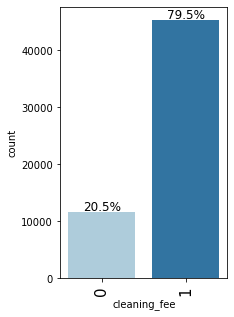

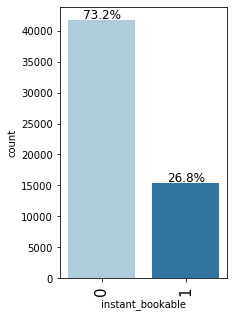

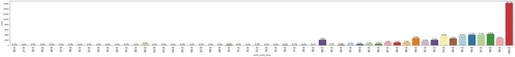

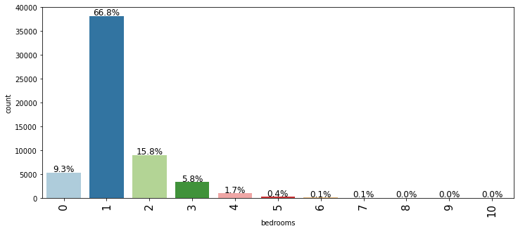

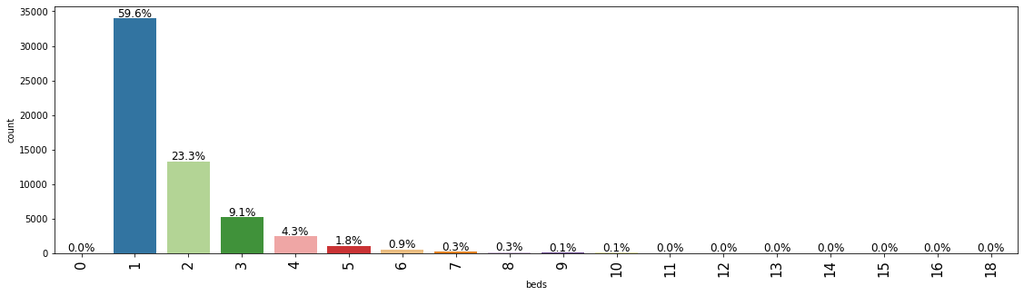

[figure not shown]

```
      room_type  accommodates  bathrooms cancellation_policy  cleaning_fee  \
0        Entire             3          1              strict             1
1        Entire             7          1              strict             1
2        Entire             5          1            moderate             1
4        Entire             2          1            moderate             1
5       Private             2          1              strict             1
...         ...           ...        ...                 ...           ...
74104    Entire             2          1              strict             1
74105   Private             2          1            moderate             1
74107    Entire             4          2            moderate             1
74108    Entire             5          1            moderate             1
74110    Entire             4          1            moderate             0

       instant_bookable  review_scores_rating  bedrooms  beds  log_price
0                     0                 100.0         1     1   5.010635
1                     1                  93.0         3     3   5.129899
2                     1                  92.0         1     3   4.976734
4                     1                  40.0         0     1   4.744932
5                     1                 100.0         1     1   4.442651
...                 ...                   ...       ...   ...        ...
74104                 0                 100.0         1     1   4.356709
74105                 0                  91.0         1     1   4.248495
74107                 0                  93.0         2     4   5.043425
74108                 1                  94.0         2     2   5.220356
74110                 0                  96.0         1     2   4.852030

[57119 rows x 10 columns]
```

```python
# Create a bar graph for all variables and check percentage
for col in df.columns:
    labeled_barplot(df, col, perc=True)
print(df)
```

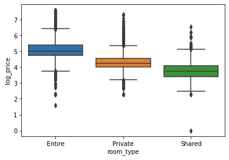

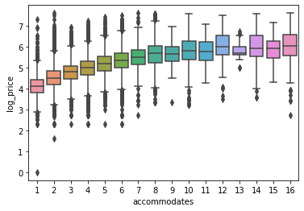

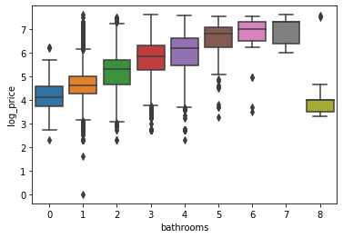

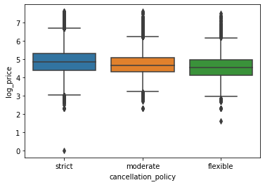

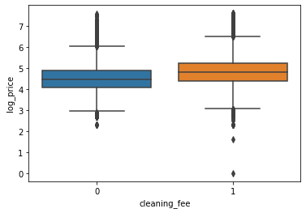

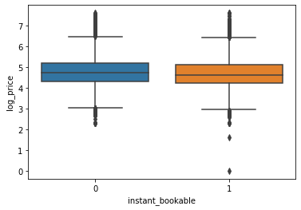

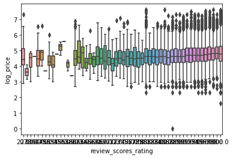

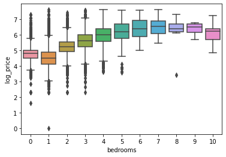

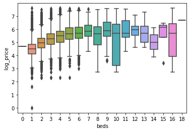

|  | count | mean | std | min | 25% | 50% | 75% | max |
| --- | --- | --- | --- | --- | --- | --- | --- | --- |
| accommodates | 57119.0 | 3.222798 | 2.146140 | 1.0 | 2.000000 | 2.00000 | 4.000000 | 16.000000 |
| bathrooms | 57119.0 | 1.186593 | 0.527531 | 0.0 | 1.000000 | 1.00000 | 1.000000 | 8.000000 |
| cleaning_fee | 57119.0 | 0.794902 | 0.403777 | 0.0 | 1.000000 | 1.00000 | 1.000000 | 1.000000 |
| instant_bookable | 57119.0 | 0.268475 | 0.443170 | 0.0 | 0.000000 | 0.00000 | 1.000000 | 1.000000 |
| review_scores_rating | 57119.0 | 94.076384 | 7.828712 | 20.0 | 92.000000 | 96.00000 | 100.000000 | 100.000000 |
| bedrooms | 57119.0 | 1.261822 | 0.842778 | 0.0 | 1.000000 | 1.00000 | 1.000000 | 10.000000 |
| beds | 57119.0 | 1.740016 | 1.266989 | 0.0 | 1.000000 | 1.00000 | 2.000000 | 18.000000 |
| log_price | 57119.0 | 4.749993 | 0.668900 | 0.0 | 4.304065 | 4.70048 | 5.164786 | 7.600402 |

```python
#Let's look at the boxplots
for col in df.columns:
    if col != "log_price":
        sns.boxplot(x=df[col], y=df["log_price"])
        plt.show()
df.describe().T
```

**accommodates** - As for the number of people it can accommodate, it seems that the two variables have a direct relationship. The price increases and subsequently stagnates.

**bathrooms** - The boxplots clearly indicate that the price increases, but there is an outlier which has 8 bathrooms with a very low price and has the potential to make large differences in the data.

**cancellation_policy** - it seems that cancellation policy doesn't matter for price. There is no correlation.

**cleaning_fee** - A cleaning fee adds a little bit to the price, but doesn't seem very poignant when compared to room type and accommodation.

**instant_bookable** - This also seems like it has no correlation.

**review_scores** - Oddly, although you would expect this to have an effect, it doesn't seem to make any difference.

**bedrooms** - The number of bedrooms has a positive correlation with the price.

**beds** - At first, it seems like it will have a positive correlation, but it stagnates in higher numbers of beds, most likely because the beds are in shared rooms, which makes the price go down.

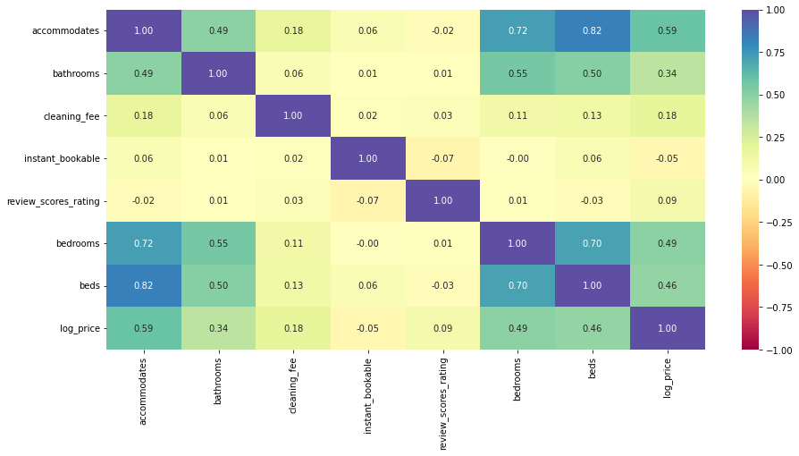

```python
# Get correlation table
cols_list = df.select_dtypes(include=np.number).columns.tolist()

plt.figure(figsize=(15, 7))
sns.heatmap(
    df[cols_list].corr(), annot=True, vmin=-1, vmax=1, fmt=".2f", cmap="Spectral"
)
plt.show()
```

As can be seen by the chart, there are very few variables with any meaningful realtionships with each other. Notable correlations:

**accommodates** and **beds** - This is fairly straightforward, more beds means more people to accomodate.

**accommodates** and **bedrooms** - More bedrooms often leads to more people being accommodated.

**accommodates** and **bathrooms** - More people in one place need more bathroomss.

**beds** and **log_price** - It follows that more people are willing to pay a larger sum to stay in one place.

**beds** and **bathrooms** - Only a certain amount of people can use a bathroom.

**bedrooms** and **bathrooms** - Bedrooms and bathrooms often go hand in hand.

```python
# Let's create the linear regression model and creating dummy variables.
X = df.drop(["log_price"], axis=1)
y = df["log_price"]
X = pd.get_dummies(
    X,
    columns=X.select_dtypes(include=["object", "category"]).columns.tolist(),
    drop_first=True,
)
x_train, x_test, y_train, y_test = train_test_split(X, y, test_size=0.3, random_state=1)
model = LinearRegression()
model.fit(x_train, y_train)
# Get coefficients
coef_df = pd.DataFrame(
    np.append(model.coef_, model.intercept_),
    index=x_train.columns.tolist() + ["Intercept"],
    columns=["Coefficients"],
)
print(coef_df)
```

```
                              Coefficients
accommodates                      0.067941
bathrooms                         0.124466
cleaning_fee                      0.000779
instant_bookable                 -0.062884
review_scores_rating              0.005849
bedrooms                          0.166617
beds                             -0.040200
room_type_Private                -0.619540
room_type_Shared                 -1.129889
cancellation_policy_moderate      0.018200
cancellation_policy_strict        0.060728
Intercept                         3.950269
```

```python
# Check to see the accuracy of the given model.
print("Training Performance:")
model_train = model_performance_regression(model, x_train, y_train)
print(model_train)
print("\n\nTest Performance:")
model_test = model_performance_regression(model, x_test, y_test)
print(model_test)
```

```
Training Performance:
       RMSE      MAE  R-squared  Adj. R-squared  MAPE
0  0.443528  0.34417   0.560012        0.559891   inf


Test Performance:
       RMSE       MAE  R-squared  Adj. R-squared      MAPE
0  0.438693  0.341878   0.570581        0.570305  7.342028
```

It seems like no amount of feature engineering or outlier removal will increase this R squared value, so it seems like this model can only predict an approximate maximum of 55.9 percent of the prices with any kind of accuracy. However, this is a fair model for the data we have and I don't believe that there is a good way to improve its efficiency.

We can see that the RMSE values are very similar. This means that this model is not overfit. The MAPE value is meaningless because of the possibility of the actual value being zero.